# Analysis of bootcamp survey

2017-08-17 10:29:46

## Goals

- Download and clean data from 2017 R Bootcamp Survey
- Visualize data
- Prepare reports in `ioslides_presentation`, `pdf_document`, and `word_document` formats

## Preliminaries

Load required packages.

```r
library(tidyverse)
library(googlesheets)
```

## Load data and examine

The survey data are stored in a [Google Sheet](https://docs.google.com/spreadsheets/d/1Ay56u6g4jyEEdlmV2NHxTLBlcjI2gHavta-Ik0kGrpg/edit#gid=896447063). We'll use the `googlesheets` package to open it and create a data frame. Documentation about the package can be found [here](https://cran.r-project.org/web/packages/googlesheets/vignettes/basic-usage.html).

There are some idiosyncrasies in using the `googlesheets` package in an R Markdown document because it requires interaction with the console, so I created a separate R script, `Get_bootcamp_googlesheet.R` to extract the survey data, clean it, and save it to a CSV under `data/survey.csv`. We can then just load this file. But, let's look at `R/Clean_survey_data.R`.

I also created a test data file, `data/survey-test.csv` so I could see how everything worked before y'all filled out your responses. The `R/Make_test_survey.R` file shows how I did this. It's a great, reproducible practice to simulate the data you expect, then run it through your pipeline.

```r
# Created test data set for testing.
# survey <- read_csv("../data/survey-test.csv")
# Or choose data from respondents
survey <- read_csv("../data/survey.csv")
survey
```

```
## # A tibble: 35 x 7
##             Timestamp `Your current level of experience/expertise with R`
##                 <chr>                                               <chr>
##  1               <NA>                                                <NA>
##  2 8/13/2017 23:29:24                                                some
##  3 8/14/2017 12:01:12                                                some
##  4 8/15/2017 12:42:09                                                some
##  5 8/15/2017 17:13:08                                                none
##  6 8/15/2017 19:03:40                                             limited
##  7 8/15/2017 23:36:07                                                some
##  8 8/15/2017 23:45:05                                             limited
##  9  8/16/2017 0:26:01                                                 pro
## 10  8/16/2017 1:09:44                                                none
## # ... with 25 more rows, and 5 more variables: `Your enthusiasm for Game
## #   of Thrones` <int>, `Age in years` <int>, `Preferred number of hours
## #   spent sleeping/day` <chr>, `Favorite day of the week` <chr>, `Are your
## #   data tidy?` <chr>
```

The `str()` or 'structure' command is also a great way to see what you've got.

```r
str(survey)
```

```
## Classes 'tbl_df', 'tbl' and 'data.frame':    35 obs. of  7 variables:
##  $ Timestamp                                        : chr  NA "8/13/2017 23:29:24" "8/14/2017 12:01:12" "8/15/2017 12:42:09" ...
##  $ Your current level of experience/expertise with R: chr  NA "some" "some" "some" ...
##  $ Your enthusiasm for Game of Thrones              : int  NA 10 10 10 10 10 10 3 9 10 ...
##  $ Age in years                                     : int  NA 28 22 24 28 24 23 25 37 25 ...
##  $ Preferred number of hours spent sleeping/day     : chr  NA "8!!!" "7" "10" ...
##  $ Favorite day of the week                         : chr  NA "Friday" "Friday" "Saturday" ...
##  $ Are your data tidy?                              : chr  NA "Yes" "That's a personal question" "No" ...
##  - attr(*, "spec")=List of 2
##   ..$ cols   :List of 7
##   .. ..$ Timestamp                                        : list()
##   .. .. ..- attr(*, "class")= chr  "collector_character" "collector"
##   .. ..$ Your current level of experience/expertise with R: list()
##   .. .. ..- attr(*, "class")= chr  "collector_character" "collector"
##   .. ..$ Your enthusiasm for Game of Thrones              : list()
##   .. .. ..- attr(*, "class")= chr  "collector_integer" "collector"
##   .. ..$ Age in years                                     : list()
##   .. .. ..- attr(*, "class")= chr  "collector_integer" "collector"
##   .. ..$ Preferred number of hours spent sleeping/day     : list()
##   .. .. ..- attr(*, "class")= chr  "collector_character" "collector"
##   .. ..$ Favorite day of the week                         : list()
##   .. .. ..- attr(*, "class")= chr  "collector_character" "collector"
##   .. ..$ Are your data tidy?                              : list()
##   .. .. ..- attr(*, "class")= chr  "collector_character" "collector"
##   ..$ default: list()
##   .. ..- attr(*, "class")= chr  "collector_guess" "collector"
##   ..- attr(*, "class")= chr "col_spec"
```

Clearly, we need to do some cleaning before we can do anything with this.

Let's start by renaming variables

```r
names(survey) <- c("Timestamp",
                  "R_exp",
                  "GoT",
                  "Age_yrs",
                  "Sleep_hrs",
                  "Fav_day",
                  "Tidy_data")
```

```r
# complete.cases() drops NAs
survey <- survey[complete.cases(survey),]
survey
```

```
## # A tibble: 34 x 7
##             Timestamp   R_exp   GoT Age_yrs Sleep_hrs  Fav_day
##                 <chr>   <chr> <int>   <int>     <chr>    <chr>
##  1 8/13/2017 23:29:24    some    10      28      8!!!   Friday
##  2 8/14/2017 12:01:12    some    10      22         7   Friday
##  3 8/15/2017 12:42:09    some    10      24        10 Saturday
##  4 8/15/2017 17:13:08    none    10      28         9 Saturday
##  5 8/15/2017 19:03:40 limited    10      24         9 Saturday
##  6 8/15/2017 23:36:07    some    10      23       6-7   Friday
##  7 8/15/2017 23:45:05 limited     3      25         8   Friday
##  8  8/16/2017 0:26:01     pro     9      37         7   Friday
##  9  8/16/2017 1:09:44    none    10      25         9 Saturday
## 10  8/16/2017 8:51:05 limited     1      23       7.5 Thursday
## # ... with 24 more rows, and 1 more variables: Tidy_data <chr>
```

Now, lets make sure we have numbers where we expect them.

```r
survey$Sleep_hrs <- readr::parse_number(survey$Sleep_hrs)
survey
```

```
## # A tibble: 34 x 7
##             Timestamp   R_exp   GoT Age_yrs Sleep_hrs  Fav_day
##                 <chr>   <chr> <int>   <int>     <dbl>    <chr>
##  1 8/13/2017 23:29:24    some    10      28       8.0   Friday
##  2 8/14/2017 12:01:12    some    10      22       7.0   Friday
##  3 8/15/2017 12:42:09    some    10      24      10.0 Saturday
##  4 8/15/2017 17:13:08    none    10      28       9.0 Saturday
##  5 8/15/2017 19:03:40 limited    10      24       9.0 Saturday
##  6 8/15/2017 23:36:07    some    10      23       6.0   Friday
##  7 8/15/2017 23:45:05 limited     3      25       8.0   Friday
##  8  8/16/2017 0:26:01     pro     9      37       7.0   Friday
##  9  8/16/2017 1:09:44    none    10      25       9.0 Saturday
## 10  8/16/2017 8:51:05 limited     1      23       7.5 Thursday
## # ... with 24 more rows, and 1 more variables: Tidy_data <chr>
```

Looks good. Let's save that cleaned file so we don't have to do this again.

```r
write_csv(survey, path="../data/survey_clean.csv")
```

We may want to make the `R_exp` variable ordered.

```r
(survey_responses <- unique(survey$R_exp))
```

```
## [1] "some"    "none"    "limited" "pro"
```

This shows us the different survey response values.

```r
survey$R_exp <- ordered(survey$R_exp, levels=c("none",
                                               "limited",
                                               "some",
                                               "lots",
                                               "pro"))
```

## Visualization

Now, we follow Mike Meyer's advice: "Plot your data!"

### Descriptive plots

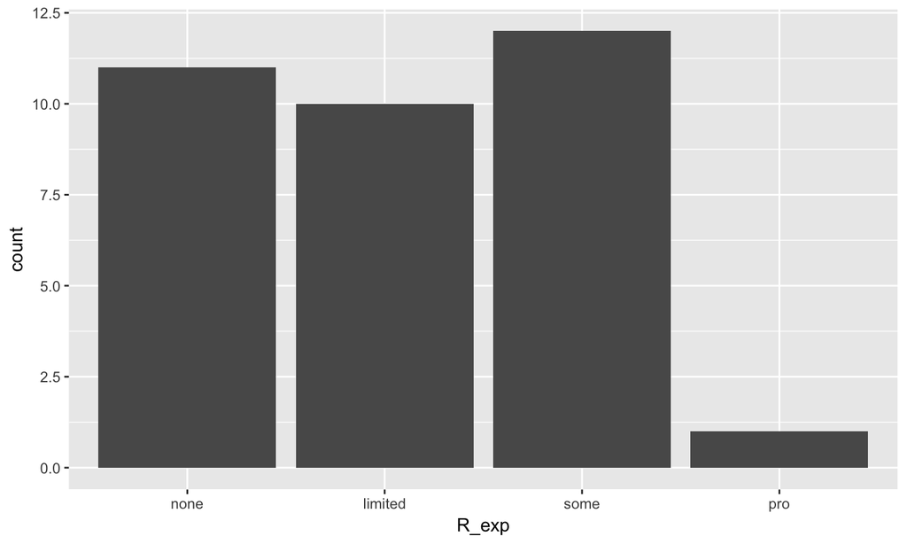

Distribution of prior R experience

```r
R_exp_hist <- survey %>%
  ggplot() +
  aes(x=R_exp) +
  geom_histogram(stat = "count") # R_exp is discrete
R_exp_hist
```

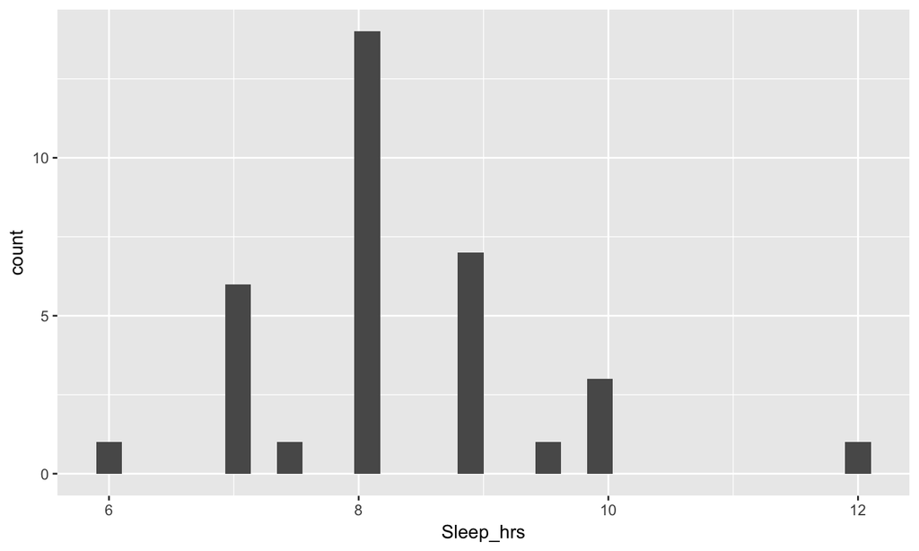

Distribution of preferred sleep hrs/day

```r
Sleep_hrs_hist <- survey %>%
  ggplot() +
  aes(x=Sleep_hrs) +
  geom_histogram() # Sleep_hrs is continuous
Sleep_hrs_hist
```

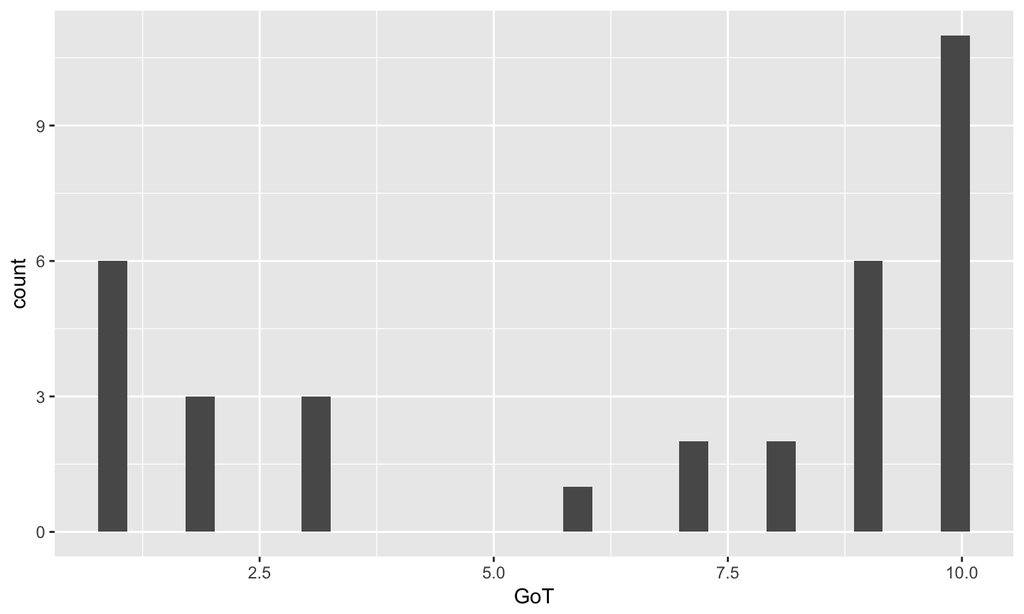

Distribution of GoT Enthusiasm

```r
Got_hist <- survey %>%
  ggplot() +
  aes(x=GoT) +
  geom_histogram()
Got_hist
```

Looks like we are of two minds about GoT.

[figure not shown]

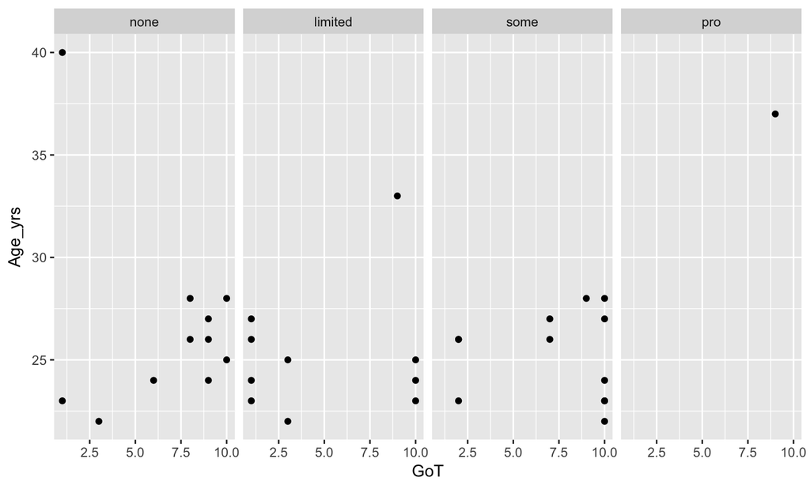

```r
GoT_vs_r_exp <- survey %>%
  ggplot() +
  aes(x=GoT, y=Age_yrs) +
  facet_grid(. ~ R_exp) +
  geom_point()
GoT_vs_r_exp
```

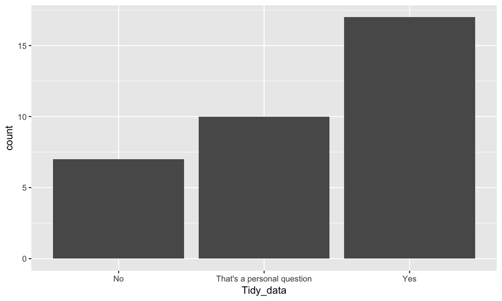

```r
tidy_hist <- survey %>%
  ggplot() +
  aes(x=Tidy_data) +
  geom_histogram(stat = "count")
tidy_hist
```

## Analysis

I could use a document like this to plan out my analysis plan **before** I conduct it. If I used simulated data, I could make sure that my workflow will run when I get real (cleaned) data. I could even preregister my analysis plan before I conduct it. That doesn't preclude later exploratory analyses, but it does hold me and my collaborators accountable for what I predicted in advance.

## Notes

Notice that I sometimes put a label like `got-vs-r-exp` in the brackets for a given 'chunk' of R code. The main reasons to do this are:

- It sometimes makes it easier to debug your code.
- In some cases, you can have this 'chunk' name serve as the file name for a figure you generate within a chunk.
- In a bit, we'll see how these chunk names are useful for making tables, figures, and equations that generate their own numbers.